# 20190625_lifespan

Tim C.

6/26/2019

### WormWatcher setup

WormWatcher data consists of lifespan and healthspan traits measured in Chris Fang-Yen’s lab, see `2019-05-24_WildIsolateUpdates.pptx` file for details on the experimental platform. In short, the data were collected with the wormwatcher robot at UPenn using 24-well plates. All 14 24-well plates have 12 strains with 2 replicates per strain. The plot below shows each of 14 plates and the lifespans for each well are plotted according to the color scale on the right. I am not breaking analysis out by unique bleach, but we could do this in the future.

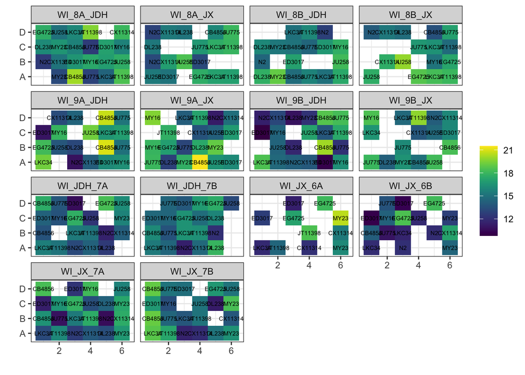

### WormWatcher traits

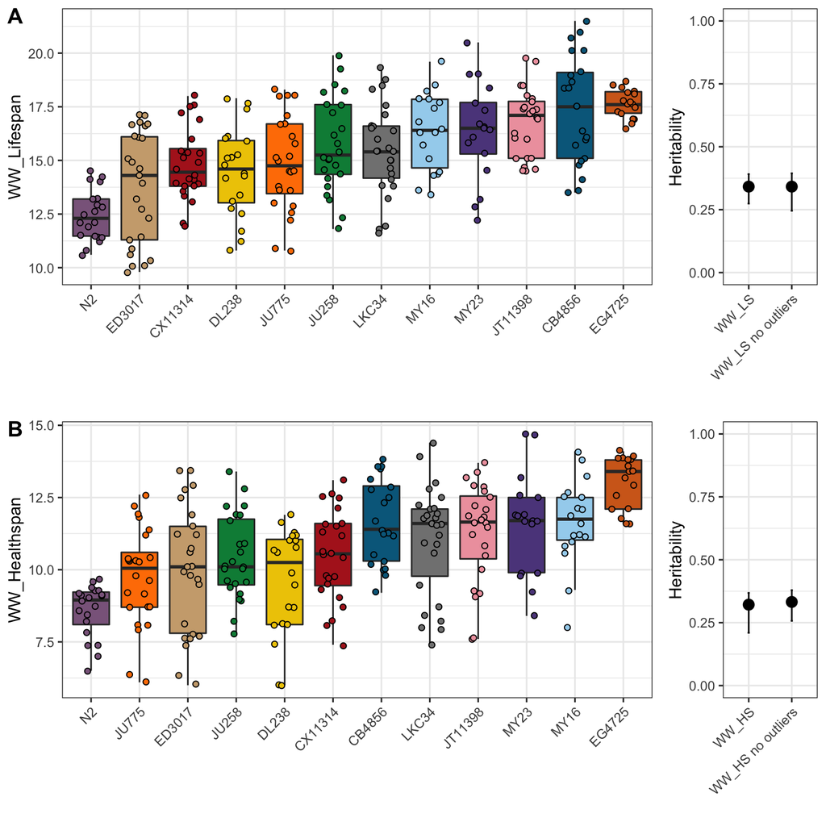

### Heritability calc.

Fit linear mixed-effects model (LMM) to data with Strain as random variable.  
`reffMod <- lme4::lmer(pheno ~ 1 + (1|strain))`  
Extract variance components for strain (Vg), and error (Ve).  
`Variances <- as.data.frame(lme4::VarCorr(reffMod, comp = "Variance"))`  
`Vg <- Variances$vcov[1]`  
`Ve <- Variances$vcov[2]`  
Calculate broad-sense heritability with variance components.  
`H2 <- Vg/(Vg+Ve)`  
Calculate 95% confidence intervals by bootstrap method.

### WormWatcher traits for plate and bleach averages

There are seven independent bleaches in the large data set, four conducted by JX, three by JDH. To get the mean value per bleach per strain I average the data for replicate wells in a plate (2 wells), then average those across technical replicate plates (2 plates). I’ve dropped one bleach from JX b/c many wells were contaminated. This gives us five to six independent bleaches per strain for analysis.

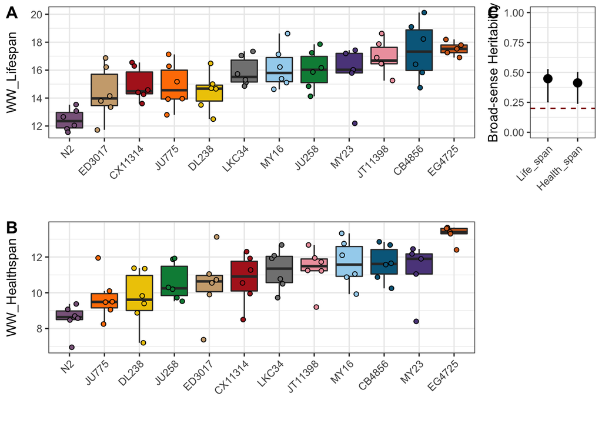